# Experiments in language evolution: inferences from closed- vs open-ended semantic space paradigms

Preparation

analysis by Aleksandra Ćwiek

24 November, 2025

# 1 What this document does

**Purpose.** This notebook loads raw data (vocalizations/gestures metadata + ConceptNet similarities), cleans and harmonizes variable names/keys, and produces a single analysis-ready table used by `2_modeling.Rmd`.

**Outputs.** (a) a cleaned CSV (`final_df.csv`) written to `data/`; (b) sanity-check summaries and quick plots saved under `plots/1_preparation/`.

# 2 Data preparation

## 2.1 Source setup

```r
########## folders ##########
library(here)

setwd(dirname(rstudioapi::getActiveDocumentContext()$path))

parentfolder <- dirname(getwd())

data          <- paste0(parentfolder, '/data/')
models        <- paste0(parentfolder, '/models/')
plots         <- paste0(parentfolder, '/plots/')
scripts       <- paste0(parentfolder, '/scripts/')

#################### packages ####################
# Core tidyverse for wrangling + plotting; janitor/skimr for quick structure checks; patchwork for combining plots
library(tidyverse)
library(janitor)
library(skimr)
library(knitr)
library(cowplot)
library(ggdist)
library(readxl)
library(lubridate)
library(patchwork)
library(hexbin)
library(PRROC)

# Keep plots/readability consistent
theme_set(theme_minimal(base_size = 12) + panel_border())

colorBlindBlack8  <- c("#000000", "#E69F00", "#56B4E9", "#009E73",
                       "#F0E442", "#0072B2", "#D55E00", "#CC79A7")
```

**Auto-saving figures.** Each plot with `fig.cap` is copied to `plots/<Rmd-name>/Figure_XX.(png|tif)`. This guarantees stable filenames for papers, corresponding to figure numbers from the html.

```r
# --- figure & table captions ---
outputFormat <- knitr::opts_knit$get("rmarkdown.pandoc.to"); if (is.null(outputFormat)) outputFormat <- ""
capTabNo <- 1L; capFigNo <- 1L
.last_fig_no <- NA_integer_

capTab <- function(x){
  if (outputFormat == 'html'){
    x <- paste0("**Table ", capTabNo, ".** ", x)
    capTabNo <<- capTabNo + 1L
  }
  x
}

capFig <- function(x, show_R_version=FALSE, show_package_versions=NULL, is_map=FALSE){
  if (outputFormat == 'html'){
    assign(".last_fig_no", capFigNo, envir = .GlobalEnv) # remember current number
    x <- paste0("**Figure ", capFigNo, ".** ", x)
    capFigNo <<- capFigNo + 1L
  }
  x
}

# --- plot hook to auto-save ---
.default_plot_hook <- knitr::knit_hooks$get("plot")
.has_magick <- requireNamespace("magick", quietly = TRUE)

knitr::knit_hooks$set(plot = function(x, options){
  res <- if (is.function(.default_plot_hook)) .default_plot_hook(x, options) else NULL

  if (!is.null(options$fig.cap)) {
    fig_no <- get(".last_fig_no", envir = .GlobalEnv, inherits = FALSE)
    if (!is.na(fig_no)) {
      fig_no_str <- sprintf("%02d", fig_no)

      # subfolder = Rmd filename without extension
      rmd_name <- tools::file_path_sans_ext(basename(knitr::current_input()))
      target_dir <- file.path(plots, rmd_name)
      if (!dir.exists(target_dir)) dir.create(target_dir, recursive = TRUE)

      png_out <- file.path(target_dir, paste0("Figure_", fig_no_str, ".png"))
      tif_out <- file.path(target_dir, paste0("Figure_", fig_no_str, ".tif"))

      file.copy(x, png_out, overwrite = TRUE)

      if (.has_magick) {
        img <- magick::image_read(png_out)
        magick::image_write(img, path = tif_out, format = "tiff", compression = "lzw")
      } else {
        file.copy(png_out, tif_out, overwrite = TRUE)
      }
    }
  }

  res
})
```

## 2.2 Load in data frames

- `vocs.xlsx` — trial-level responses (free text), one row per participant×stimulus.
- `all_metadata.xlsx` — stimulus metadata (concept, modality, etc.).
- `cosine_sim.csv` — ConceptNet cosine between response head and target concept; first row is a header row from export and is promoted to column names here.

**Harmonization.** We `clean_names()` so joins are predictable; cosine is coerced to numeric after header fix.

```r
vocs <- read_excel(paste0(data, "vocs.xlsx"))  %>% clean_names()
meta <- read_excel(paste0(data, "all_metadata.xlsx"))  %>% clean_names()

cn <- read_delim(paste0(data, "cosine_sim.csv"), delim = ';') %>% clean_names()
colnames(cn) <- as.character(cn[1,])
cn <- cn[-1,]
cn$cosine_similarity <- as.numeric(cn$cosine_similarity)
```

## 2.3 Clean and prep data frame

```r
## ---------- 1) Normalize vocs & cn ----------
vocs_keys <- vocs %>%
  mutate(
    right_answer_key = str_squish(tolower(right_answer)),
    answer_key       = str_squish(tolower(answer))
  )

cn_keys <- cn %>%
  rename(right_answer = Right_answer,
         answer       = Answer,
         cosine_similarity = cosine_similarity) %>%
  mutate(
    right_answer_key = str_squish(tolower(right_answer)),
    answer_key       = str_squish(tolower(answer))
  )

## ---------- 2) Fix final_decision ----------
vocs_fixed <- vocs_keys %>%
  mutate(
    final_decision    = ifelse(final_decision == 31, 2, final_decision),
    judged_similarity = final_decision,
    binary_guess      = ifelse(final_decision == 3, 1, 0)
  )

## ---------- 3) Clean native_language ----------
meta_lang <- meta %>%
  mutate(
    native_language = native_language %>%
      str_squish() %>%
      str_replace_all("[[:punct:]]+$", "") %>%
      str_trim(),
    nl_low = tolower(native_language),
    native_language = case_when(
      str_detect(nl_low, "english") ~ "English",
      nl_low %in% c("enlgish") ~ "English",
      str_detect(nl_low, "spanish") ~ "Spanish",
      str_detect(nl_low, "portugu") ~ "Portuguese",
      nl_low %in% c("portuguesa", "pirtuguese", "portugal") ~ "Portuguese",
      nl_low %in% c("italiano") | str_detect(nl_low, "^italian") ~ "Italian",
      str_detect(nl_low, "hebrew") ~ "Hebrew",
      str_detect(nl_low, "oromo|ormo") ~ "Oromo",
      str_detect(nl_low, "zulu") ~ "Zulu",
      TRUE ~ str_to_title(nl_low)
    )
  )

## ---------- 4) Time & coverage filters (session-level) ----------
per_part <- meta_lang %>%
  group_by(rec_session_id) %>%
  summarise(
    completed_all = all(completed, na.rm = TRUE),
    n_rows = n(),
    start_min = suppressWarnings(min(start_time, na.rm = TRUE)),
    end_max   = suppressWarnings(max(end_time,   na.rm = TRUE)),
    duration_min = as.numeric(difftime(end_max, start_min, units = "mins")),
    .groups = "drop"
  )

# Relative coverage vs. max rows recorded in meta for any participant
max_rows <- max(per_part$n_rows, na.rm = TRUE)

per_part <- per_part %>%
  mutate(
    pct_trials = n_rows / max_rows,
    reason_excl_session = case_when(
      !completed_all ~ "Not completed",
      pct_trials < 0.90 ~ "<90% trials",
      duration_min < 2 ~ "Too short (<2m)",
      duration_min > 100 ~ "Too long (>100m)",
      TRUE ~ NA_character_
    )
  )

## ---------- 5) Per-trial IQR outlier detection (within participant) ----------
# We attempt trial-level durations from meta (one row per trial is ideal).
# If only 1 row per participant, this step safely does nothing.
meta_trials <- meta_lang %>%
  select(rec_session_id, trial_id, start_time, end_time) %>%
  mutate(trial_dur_min = as.numeric(difftime(end_time, start_time, units = "mins"))) %>%
  filter(!is.na(trial_dur_min))

per_trial_outliers <- meta_trials %>%
  group_by(rec_session_id) %>%
  mutate(
    n_trials_avail = n(),
    Q1 = quantile(trial_dur_min, 0.25, na.rm = TRUE),
    Q3 = quantile(trial_dur_min, 0.75, na.rm = TRUE),
    IQRv = IQR(trial_dur_min, na.rm = TRUE),
    low_f = Q1 - 1.5 * IQRv,
    high_f = Q3 + 1.5 * IQRv,
    is_outlier = trial_dur_min < low_f | trial_dur_min > high_f
  ) %>%
  summarise(
    n_trials_avail = first(n_trials_avail),
    outlier_share = mean(is_outlier, na.rm = TRUE),
    reason_excl_trial = case_when(
      n_trials_avail >= 5 & outlier_share > 0.20 ~ "Per-trial time outliers >20% (IQR)",
      TRUE ~ NA_character_
    ),
    .groups = "drop"
  )

# Merge session reasons + per-trial reasons
per_part <- per_part %>%
  left_join(per_trial_outliers, by = "rec_session_id") %>%
  mutate(
    reason_exclusion = case_when(
      !is.na(reason_excl_session) & !is.na(reason_excl_trial) ~ paste(reason_excl_session, reason_excl_trial, sep = "; "),
      !is.na(reason_excl_session) ~ reason_excl_session,
      !is.na(reason_excl_trial) ~ reason_excl_trial,
      TRUE ~ NA_character_
    )
  ) %>%
  select(rec_session_id, n_rows, pct_trials, duration_min, outlier_share, reason_exclusion)

# Keep & exclude IDs
keep_ids <- per_part %>%
  filter(is.na(reason_exclusion)) %>%
  transmute(rec_session_id_chr = as.character(rec_session_id))

exclusion_report <- per_part %>%
  filter(!is.na(reason_exclusion)) %>%
  transmute(
    participant = as.character(rec_session_id),
    reason_exclusion,
    n_rows, pct_trials, duration_min, outlier_share
  )

exclusion_summary <- exclusion_report %>%
  separate_rows(reason_exclusion, sep = ";\\s*") %>%
  count(reason_exclusion, sort = TRUE)

## ---------- 6) Participant IDs from coder_id + corrections ----------
vocs_fixed <- vocs_fixed %>%
  mutate(
    participant = str_extract(coder_id, "\\d+"),
    participant = as.character(participant),
    participant = case_when(
      participant == "113978"   ~ "1113978",
      participant == "114003"   ~ "1114003",
      participant == "11134822" ~ "1113482",
      participant == "11112900" ~ "1112900",
      participant == "11129907" ~ "1112907",
      participant == "11129917" ~ "1112917",
      participant == "11129918" ~ "1112918",
      TRUE ~ participant
    )
  )

## ---------- 7) Merge cosine ----------
vocs_cn <- vocs_fixed %>%
  left_join(cn_keys %>% select(right_answer_key, answer_key, cosine_similarity),
            by = c("right_answer_key", "answer_key"))

## ---------- 8) Further cleanup meta ----------

meta_lang <- meta_lang %>%
  rename(environment = environment_choice) %>%
  mutate(
    environment = case_when(
      environment == "option_0" ~ "home",
      environment == "option_1" ~ "transport",
      environment == "option_2" ~ "another public space",
      environment == "option_3" ~ "other",
      TRUE ~ NA_character_
    ),
    audio_device = case_when(
      audio_device == "option_0" ~ "speaker",
      audio_device == "option_1" ~ "headphones",
      audio_device == "option_2" ~ "other",
      TRUE ~ NA_character_
    ),
    text_device = case_when(
      text_device == "option_0" ~ "computer",
      text_device == "option_1" ~ "phone",
      text_device == "option_2" ~ "other",
      TRUE ~ NA_character_
    )
  )


## ---------- 9) Final df (filter to kept participants first) ----------
df <- vocs_cn %>%
  semi_join(keep_ids, by = c("participant" = "rec_session_id_chr")) %>%
  left_join(
    meta_lang %>%
      mutate(rec_session_id_chr = as.character(rec_session_id)) %>%
      select(
        rec_session_id_chr,
        native_language,
        text_device,
        audio_device,
        environment,
        hearing_disabilities,
        toughness,
        quantity
      ),
    by = c("participant" = "rec_session_id_chr")
  ) %>%
  transmute(
    participant,
    native_language,
    hearing_disabilities,
    environment,
    audio_device,
    text_device,
    toughness,
    quantity_guessed = quantity,
    trial_id,
    stimulus_concept = right_answer,
    guessed_concept  = answer,
    binary_guess,
    judged_similarity,
    cosine_similarity
  )

## ---------- 10) Cleanup environment ----------
rm(vocs_keys, cn_keys, vocs_fixed, meta_lang, meta_trials, per_trial_outliers,
   per_part, max_rows, keep_ids, vocs_cn)

## ---------- 11) Outputs ----------
# df                 -> final dataset
# exclusion_report   -> detailed rows (participant-level) with reason(s)
# exclusion_summary  -> counts per reason
# check which rows are NA in cosine_similarity
# df %>% filter(is.na(cosine_similarity)) %>% nrow()
```

Check final df.

```r
skim(df)
```

Data summary

| Name | df |
| --- | --- |
| Number of rows | 27279 |
| Number of columns | 14 |
| _______________________ |  |
| Column type frequency: |  |
| character | 7 |
| logical | 1 |
| numeric | 6 |
| ________________________ |  |
| Group variables | None |

**Variable type: character**

| skim_variable | n_missing | complete_rate | min | max | empty | n_unique | whitespace |
| --- | --- | --- | --- | --- | --- | --- | --- |
| participant | 0 | 1 | 7 | 7 | 0 | 200 | 0 |
| native_language | 0 | 1 | 3 | 10 | 0 | 26 | 0 |
| environment | 0 | 1 | 4 | 20 | 0 | 3 | 0 |
| audio_device | 0 | 1 | 5 | 10 | 0 | 3 | 0 |
| text_device | 0 | 1 | 5 | 8 | 0 | 3 | 0 |
| stimulus_concept | 0 | 1 | 3 | 6 | 0 | 30 | 0 |
| guessed_concept | 0 | 1 | 2 | 54 | 0 | 7162 | 0 |

**Variable type: logical**

| skim_variable | n_missing | complete_rate | mean | count |
| --- | --- | --- | --- | --- |
| hearing_disabilities | 0 | 1 | 0.01 | FAL: 27137, TRU: 142 |

**Variable type: numeric**

| skim_variable | n_missing | complete_rate | mean | sd | p0 | p25 | p50 | p75 | p100 | hist |
| --- | --- | --- | --- | --- | --- | --- | --- | --- | --- | --- |
| toughness | 0 | 1.00 | 3.23 | 0.94 | 1.00 | 3.00 | 3.00 | 4.00 | 5 | ▁▃▇▆▂ |
| quantity_guessed | 0 | 1.00 | 2.64 | 0.77 | 1.00 | 2.00 | 3.00 | 3.00 | 5 | ▁▆▇▂▁ |
| trial_id | 0 | 1.00 | 46.21 | 25.70 | 1.00 | 25.00 | 47.00 | 68.00 | 90 | ▇▇▇▇▇ |
| binary_guess | 0 | 1.00 | 0.05 | 0.21 | 0.00 | 0.00 | 0.00 | 0.00 | 1 | ▇▁▁▁▁ |
| judged_similarity | 0 | 1.00 | 0.29 | 0.77 | 0.00 | 0.00 | 0.00 | 0.00 | 3 | ▇▁▁▁▁ |
| cosine_similarity | 1416 | 0.95 | 0.18 | 0.24 | -0.16 | 0.02 | 0.09 | 0.22 | 1 | ▇▆▂▁▁ |

Rescale cosine similarity (from −1–1 to 0–1).

```r
df <- df %>%
  mutate(
    cosine_rescaled = (cosine_similarity + 1)/2,          # -1..1 → 0..1
    ord_norm        = judged_similarity/3,                 # 0..3 → 0..1
    ord_f           = factor(judged_similarity, levels = 0:3),
    bin_f           = factor(binary_guess, levels = c(0,1))
  )

# For binning cosine
df_bins <- df %>%
  filter(!is.na(cosine_rescaled)) %>%
  mutate(cos_decile = ntile(cosine_rescaled, 10))
```

# 3 Descriptive statistics

First sense of means and sd.

```r
df %>%
  summarise(
    n = n(),
    binary_mean = mean(binary_guess),
    binary_sd   = sd(binary_guess),
    ord_mean    = mean(judged_similarity),
    ord_sd      = sd(judged_similarity),
    cos_org_mean    = mean(cosine_similarity, na.rm=TRUE),
    cos_org_sd      = sd(cosine_similarity, na.rm=TRUE),
    cos_res_mean    = mean(cosine_rescaled, na.rm=TRUE),
    cos_res_sd      = sd(cosine_rescaled, na.rm=TRUE)
  )
```

| n | binary_mean | binary_sd | ord_mean | ord_sd | cos_org_mean | cos_org_sd | cos_res_mean | cos_res_sd |
| --- | --- | --- | --- | --- | --- | --- | --- | --- |
| 27279 | 0.04838887 | 0.2145905 | 0.2899666 | 0.7697914 | 0.1753931 | 0.2430106 | 0.5876966 | 0.1215053 |

Per-concept.

```r
df %>%
  group_by(stimulus_concept) %>%
  summarise(
    n = n(),
    mean_binary = mean(binary_guess),
    mean_judged = mean(judged_similarity),
    mean_cos_org = mean(cosine_similarity, na.rm = TRUE),
    mean_cos_res = mean(cosine_rescaled, na.rm = TRUE)
  ) %>%
  arrange(desc(mean_binary))
```

| stimulus_concept | n | mean_binary | mean_judged | mean_cos_org | mean_cos_res |
| --- | --- | --- | --- | --- | --- |
| eat | 1127 | 0.4259094942 | 1.328305235 | 0.56273002 | 0.7813650 |
| sleep | 1566 | 0.3212005109 | 2.203065134 | 0.75087103 | 0.8754355 |
| snake | 827 | 0.1330108827 | 0.401451028 | 0.19262922 | 0.5963146 |
| water | 923 | 0.0866738895 | 0.269772481 | 0.33362795 | 0.6668140 |
| cut | 784 | 0.0803571429 | 0.307397959 | 0.14906037 | 0.5745302 |
| child | 1040 | 0.0173076923 | 0.165384615 | 0.19328698 | 0.5966435 |
| tiger | 1036 | 0.0154440154 | 0.194015444 | 0.18587554 | 0.5929378 |
| fire | 836 | 0.0143540670 | 0.056220096 | 0.13985065 | 0.5699253 |
| cook | 778 | 0.0141388175 | 0.046272494 | 0.06903657 | 0.5345183 |
| hunt | 854 | 0.0093676815 | 0.059718970 | 0.14206501 | 0.5710325 |

[output cut: 20 more lines]

Cross-tab of binary vs ordinal.

```r
table(df$binary_guess, df$judged_similarity)
```

```
##
##         0     1     2     3
##   0 23323  1322  1314     0
##   1     0     0     0  1320
```

## 3.1 Descriptive statistics

Create a participant-level dataset

```r
df_p <- df %>%
  group_by(participant) %>%
  summarise(
    native_language     = first(native_language),
    hearing_disabilities = first(hearing_disabilities),
    environment         = first(environment),
    audio_device        = first(audio_device),
    text_device         = first(text_device),
    # numeric variables: average per participant
    toughness_mean      = mean(toughness, na.rm = TRUE),
    quantity_mean       = mean(quantity_guessed, na.rm = TRUE)
  )

freq <- function(x) {
  as.data.frame(table(x)) %>%
    mutate(
      percent = round(100 * Freq / sum(Freq), 2)
    ) %>%
    arrange(desc(Freq))
}
```

**Number of participants**

```r
n_distinct(df$participant)
```

```
## [1] 200
```

**Distributions of native languages**

```r
freq(df_p$native_language)
```

| x | Freq | percent |
| --- | --- | --- |
| English | 54 | 27.0 |
| Portuguese | 41 | 20.5 |
| Spanish | 30 | 15.0 |
| Polish | 19 | 9.5 |
| Italian | 14 | 7.0 |
| Afrikaans | 7 | 3.5 |
| Greek | 5 | 2.5 |
| Cantonese | 3 | 1.5 |
| Estonian | 3 | 1.5 |
| Hungarian | 3 | 1.5 |

[output cut: 16 more lines]

**Distribution of hearing disabilities**

```r
freq(df_p$hearing_disabilities)
```

| x | Freq | percent |
| --- | --- | --- |
| FALSE | 199 | 99.5 |
| TRUE | 1 | 0.5 |

Most of the participants (99.5%) did not have any hearing disabilities, except for one person who took part in the experiment.

**Distribution of the environment**

```r
freq(df_p$environment)
```

| x | Freq | percent |
| --- | --- | --- |
| home | 188 | 94 |
| other | 10 | 5 |
| another public space | 2 | 1 |

94% of the participants were home with only 5% in an unspecified location and 1% in a public space.

**Distribution of the audio device**

```r
freq(df_p$audio_device)
```

| x | Freq | percent |
| --- | --- | --- |
| headphones | 110 | 55 |
| speaker | 88 | 44 |
| other | 2 | 1 |

Most speakers wore headphones (55%), followed by those who used speakers (44%), and other devices (1%).

**Distribution of the input device**

```r
freq(df_p$text_device)
```

| x | Freq | percent |
| --- | --- | --- |
| computer | 177 | 88.5 |
| phone | 21 | 10.5 |
| other | 2 | 1.0 |

88.5% of the participants used a computer, 10.5% used a smartphone, and 1% used another device.

**Toughness rating**

```r
df_p %>%
  summarise(
    mean  = mean(toughness_mean),
    sd    = sd(toughness_mean),
    min   = min(toughness_mean),
    max   = max(toughness_mean)
  )
```

| mean | sd | min | max |
| --- | --- | --- | --- |
| 3.25 | 0.9391004 | 1 | 5 |

```r
freq(df_p$toughness_mean)
```

| x | Freq | percent |
| --- | --- | --- |
| 3 | 81 | 40.5 |
| 4 | 64 | 32.0 |
| 2 | 32 | 16.0 |
| 5 | 16 | 8.0 |
| 1 | 7 | 3.5 |

**Quantity guessed**

```r
df_p %>%
  summarise(
    mean  = mean(quantity_mean),
    sd    = sd(quantity_mean),
    min   = min(quantity_mean),
    max   = max(quantity_mean)
  )
```

| mean | sd | min | max |
| --- | --- | --- | --- |
| 2.625 | 0.7793664 | 1 | 5 |

```r
freq(df_p$quantity_mean)
```

| x | Freq | percent |
| --- | --- | --- |
| 3 | 93 | 46.5 |
| 2 | 72 | 36.0 |
| 4 | 21 | 10.5 |
| 1 | 13 | 6.5 |
| 5 | 1 | 0.5 |

# 4 Visual exploration

```r
# Seed for jitter
set.seed(1708)
```

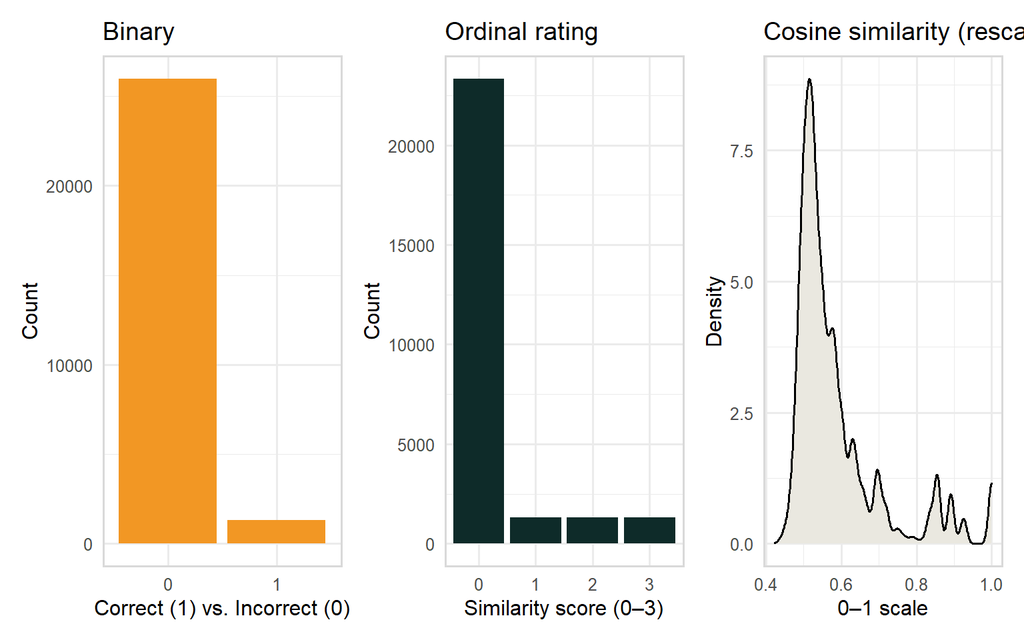

**Figure 1.** Distributions of each measure.

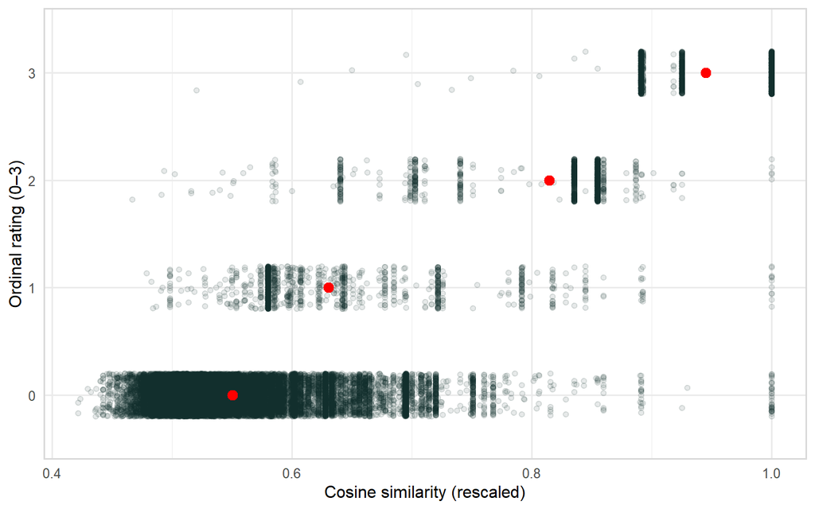

**Figure 2.** Ordinal ratings vs cosine similarity.

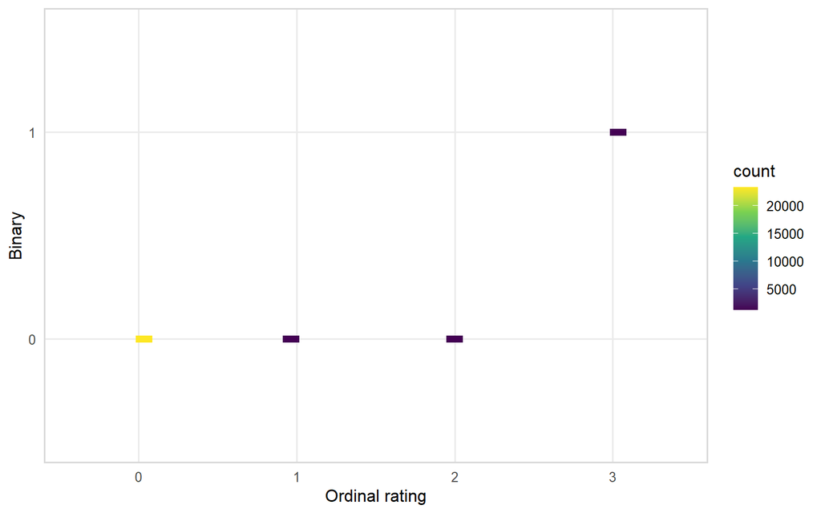

**Figure 3.** Heatmap: binary × ordinal.

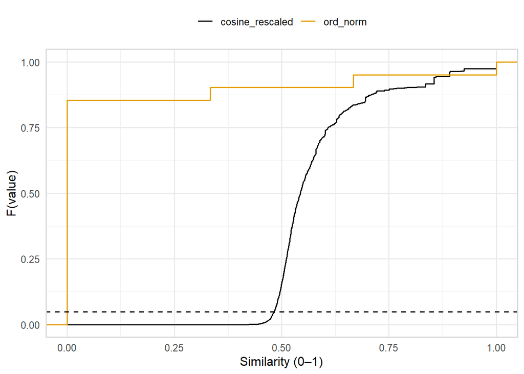

**Figure 4.** Empirical cumulative distributions of normalized ordinal similarity (0–1) and rescaled cosine similarity (0–1). The dashed horizontal line marks the overall proportion of binary successes. Differences between ECDFs indicate distinct partitioning of the response space by human ratings and computational similarity; the binary baseline shows how frequently the strict criterion is met.

If the cosine ECDF lies to the right of the ordinal ECDF, cosine assigns higher similarity more often; if left, it’s more conservative. The dashed line (binary mean) highlights how much graded signal exists below the strict “hit” rate.

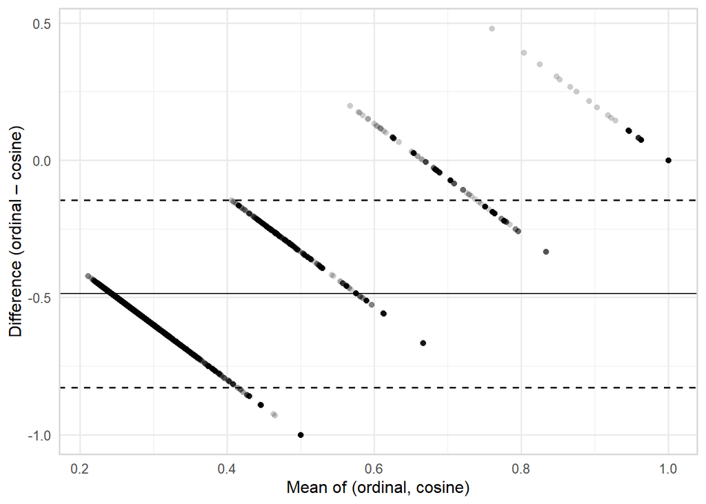

**Figure 5.** Bland–Altman plot comparing normalized ordinal similarity and rescaled cosine similarity: difference (ordinal − cosine) versus their mean. Solid line shows mean bias; dashed lines show ±1.96 SD limits of agreement. Systematic deviations from zero indicate directional disagreement; funneling suggests heteroscedasticity.

Points above zero mean humans rated higher than cosine; below zero means cosine outruns human ratings. If spread widens at higher means, the two measures diverge more for “more similar” responses.

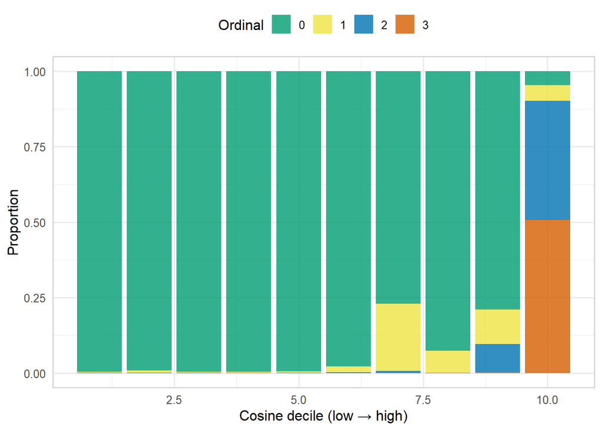

**Figure 6.** Stacked proportions of ordinal categories (0–3) across deciles of rescaled cosine similarity. Increasing shares of higher ordinal categories with higher cosine deciles indicate convergence between computational and human-graded similarity.

Watch the bars: if the “2” and “3” slices expand toward the right, cosine aligns with human-perceived similarity. Flat or noisy profiles imply weak alignment.

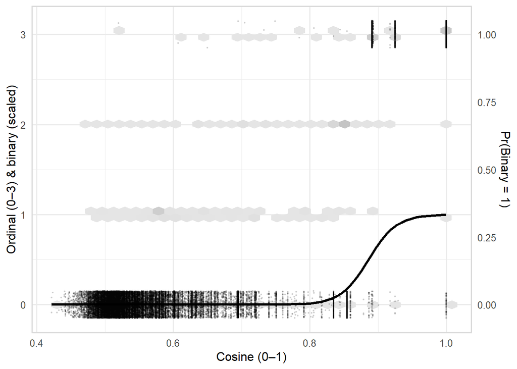

**Figure 7.** Joint distribution of rescaled cosine similarity and ordinal ratings, with the fitted logistic decision boundary for binary correctness (binary scaled to 0–3 for overlay). Kernel contours (or hexbin density) summarize mass in the graded space; the logistic curve indicates where responses cross into binary “correct.”

Dense regions at mid-to-high cosine and mid ordinal values reveal near-misses. The logistic curve shows the effective cosine threshold required for binary success.

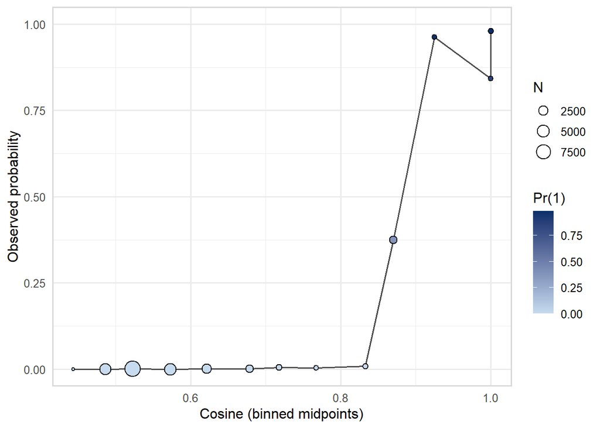

**Figure 8.** Observed probability of binary correctness as a function of binned cosine similarity. Points are sized by bin counts and colored by observed probability. The curve indicates how increases in computational similarity translate into strict success.

Monotonic rise = good calibration; plateaus or step-like jumps indicate thresholds. Large, pale points with low p show regions with many attempts but low strict success.

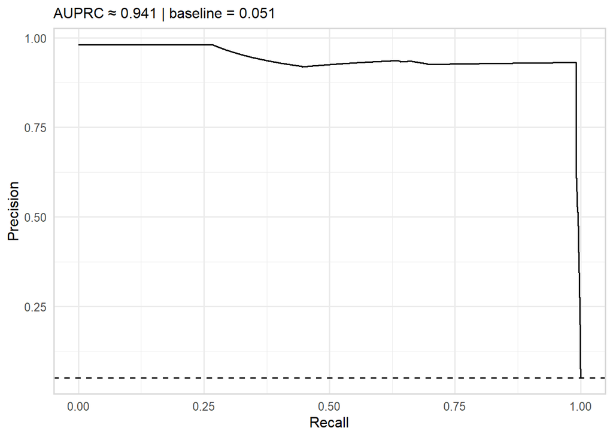

**Figure 9.** Precision–Recall curve using rescaled cosine similarity as a decision score for predicting binary correctness under class imbalance. Dashed horizontal line marks the baseline prevalence. Area under the PR curve (AUPRC) quantifies utility beyond prevalence.

If the PR curve stays well above the baseline, cosine is informative for the hard task. A rapid precision drop at higher recall signals many false positives among “near-similar” cases.

| n_total | n_nm_cos70 | n_nm_ord2 | frac_nm_cos70 | frac_nm_ord2 |
| --- | --- | --- | --- | --- |
| 25863 | 2052 | 1291 | 0.07934114 | 0.04991687 |

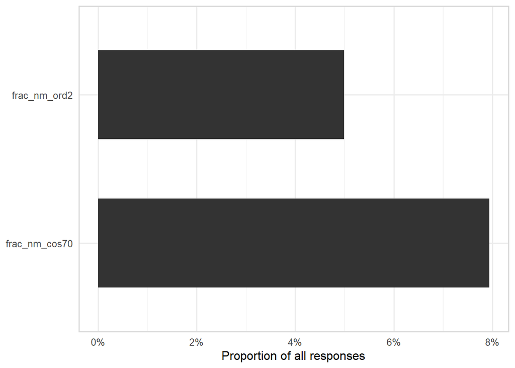

**Figure 10.** Proportions of responses that are binary failures (0) yet exceed a high-similarity threshold either in cosine (e.g., ≥ .70) or in ordinal ratings (≥ 2). Bars show the share of “discarded but semantically close” responses.

These are the cases the abstract cares about: they are wrong by the strict criterion but meaningfully similar by graded/computational measures. Higher bars = more nuance lost by binary.

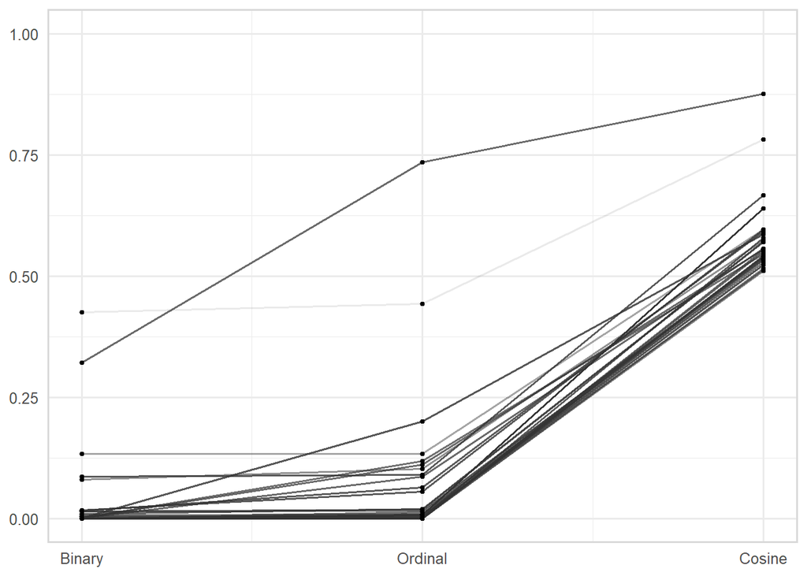

**Figure 11.** For each stimulus concept, lines connect mean scores on Binary (proportion), Ordinal (normalized), and Cosine (rescaled). Line opacity encodes the within-item spread (max–min). Diverging trajectories indicate disagreement across measures at the item level.

Look for items whose lines climb from Binary to Ordinal/Cosine: these are systematically “rescued” by graded measures. Flat lines indicate consensus across metrics.

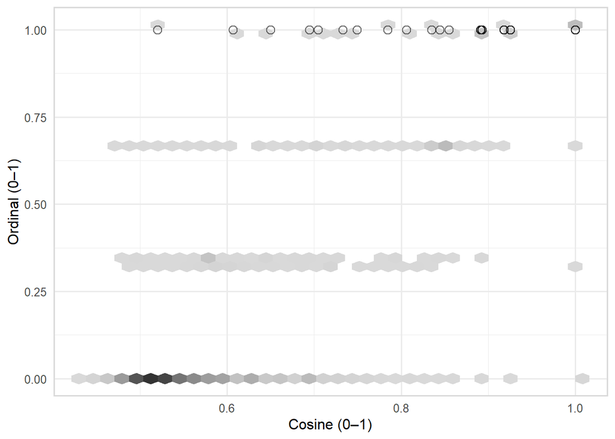

**Figure 12.** Hexbin density of rescaled cosine similarity versus normalized ordinal similarity, with binary successes overlaid as open circles. Shading reflects observations per hexagon.

If successes cluster at the upper-right, binary hits require both high cosine and high ordinal. Sparse, isolated success markers reveal “lucky hits” or boundary cases.

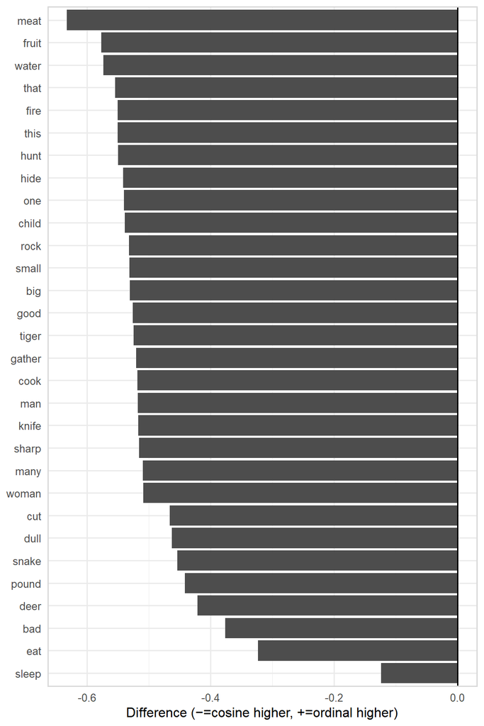

**Figure 13.** Stimulus concepts ranked by absolute disagreement between mean normalized ordinal similarity and mean rescaled cosine similarity. Positive bars indicate higher human ratings than cosine; negative bars indicate higher cosine than human ratings.

This is the case-study list. Positive extremes: humans perceive similarity that cosine underestimates (e.g., pragmatic or contextual ties). Negative extremes: cosine overestimates semantic closeness relative to human perception.

# 5 Export df

**Output.** We write a single analysis-ready CSV (`final_df.csv`) consumed by `2_modeling.Rmd`.

```r
write_csv(df, paste0(data, "final_df.csv"))
```